# Time Series Analysis:

## Definitions and Reference Material

#### Not sure how this file is going to work yet!

[Visit my website](http://www.rmdk.ca/projects%5D) for more like this! I would love to hear your feedback (seriously).

```r
library(TSA, quietly=TRUE, warn.conflicts=FALSE)
```

```
## Error: there is no package called 'TSA'
```

```r
require(knitr)
library(ggplot2)
```

#### Data Sources:

Heavily borrowed from: Textbook: [Time Series Analysis and It's Application](http://books.google.ca/books/about/Time_Series_Analysis_and_Its_Application.html?id=ahdvcgAACAAJ&redir_esc=y)

[Wikipedia](http://en.wikipedia.org/wiki/Stationary_process)

## 1.0 Basic Examples and Definitions

The next few examples are representations of common types of time series. We then defined some terms and theory that are useful to understand prior to moving onto real analysis.

### Ex 1.00: Moving Averages

Consider some white noise, smoothed by a moving average using `filter()`. This smoother representation eliminates some of the faster oscillations, and leaves us with a more representative trend.

```r
set.seed(1122)
d<-rnorm(500, 0, 1) # 500 samples between 0, 1
D<-filter(d, sides=2, rep(1/3, 3))
```

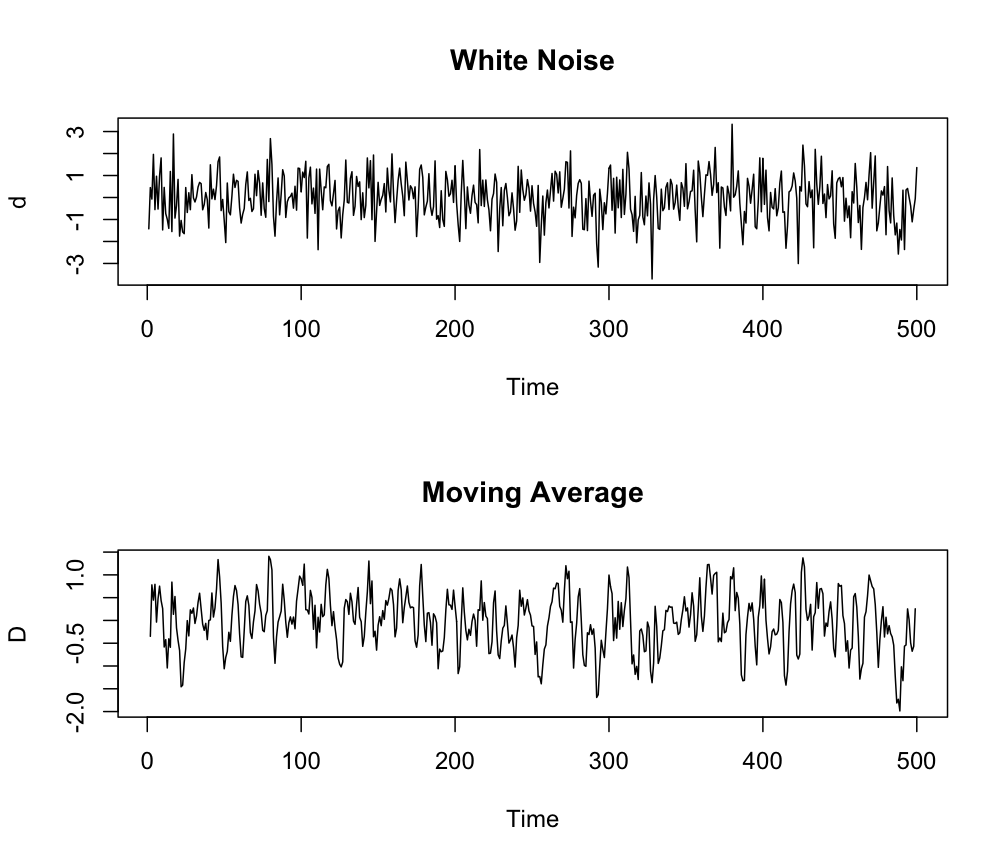

```r
par(mfrow=c(2,1))
plot.ts(d, main='White Noise')
plot.ts(D, main='Moving Average')
```